# Applied Generalized Linear (Mixed) Modelling

Benedikt Ehinger

2026-09-11

```
swarm_along_x! (generic function with 1 method)
```

```
make_fig (generic function with 2 methods)
```

## Slides & my Presentation style

Click this link to add notes to the slides

this adds `?showNotes=true` to the file

You can download the pdf or print them yourself:

click this link for pdf printable (use google chrome)

click this link for pdf printable + notes

HTML is best viewed in chrome

# Purpose of Statistics

## Purpose of statistics

- Organization

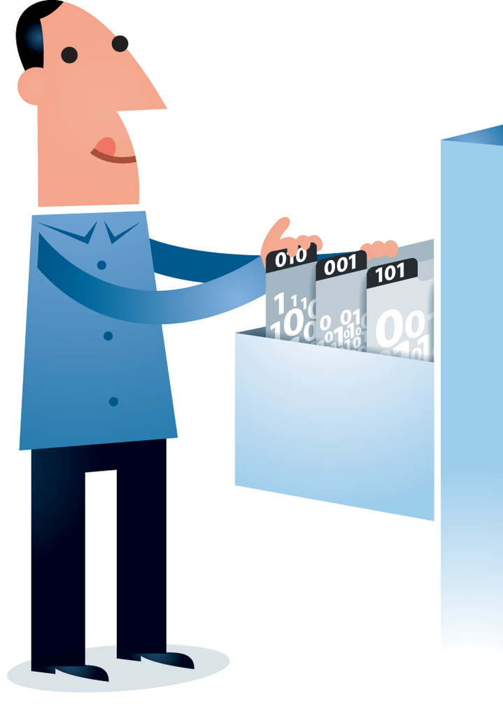

- Description

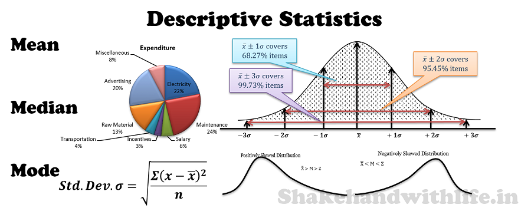

- Inference

## Why statistics in the first place?

**Because of Variation**

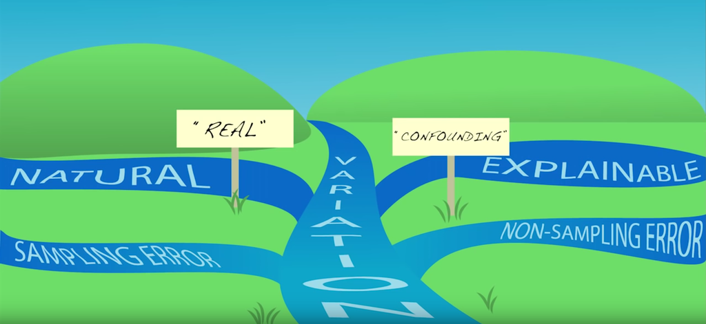

sources of variation

[source-youtube-video of image](https://www.youtube.com/watch?v=y3A0lUkpAko)

## Most important lesson

**Always visualize your data**

> …make both calculations and graphs. Both sorts of output should be studied; each will contribute to understanding. F. J. Anscombe, 1973

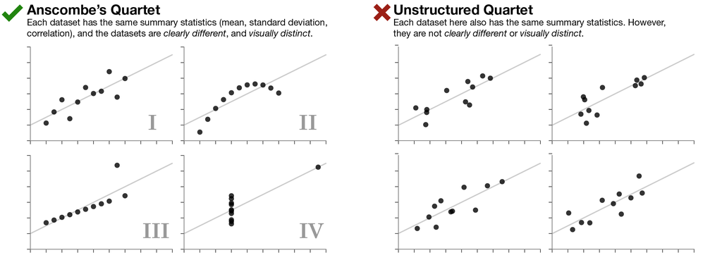

distributions

These data all have the same mean + variance + correlation!

[figure not shown]

dino

# A leading example

## Button Pressing Experiment

2×2 DataFrame

| Row | round_square String | reactiontime Float64 |
| --- | --- | --- |
| 1 | round | 202.222 |
| 2 | square | 217.193 |

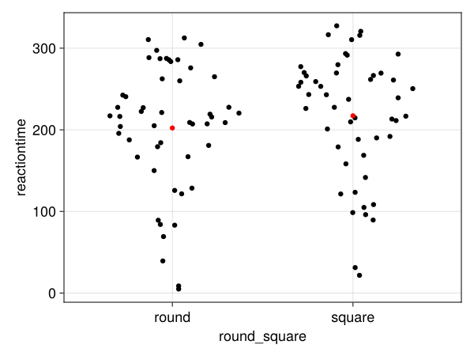

```julia
data(d) * mapping(:round_square,:reactiontime) * visual(Beeswarm;algorithm=:pseudorandom) |> draw
data(d_mean) * mapping(:round_square,:reactiontime) * visual(Scatter,color=:red) |> x->draw!(current_axis(),x)

current_figure()
```

## There could be confounds!

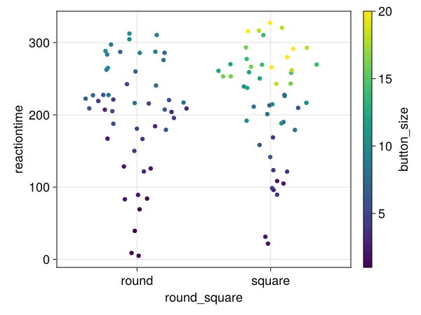

```julia
data(d) * mapping(:round_square,:reactiontime,color=:button_size) * visual(Beeswarm;algorithm=:pseudorandom) |> draw
```

## Preview: Multiple regression to the rescue

$reactiontime = Average + isRound + buttonSize$

$reactiontime = \beta_{average} + \beta_1 \cdot isRound + \beta_2 \cdot buttonSize$

> - Linear Models allow to structure and separate effects
> - Linear Models allow to predict values (e.g. what if button-size would be double the size?)
> - Linear Models can be easily extended for non-linear effects (e.g. GAM), complicated distributions(e.g. Yes/No aka logistic regression) or multiple outcomes (General Linear Model)

# Linear Regression

## The simple linear regression

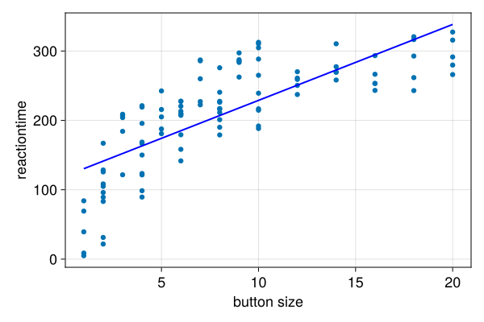

```julia
fit = lm(@formula(reactiontime ~ 1 + button_size), d)
```

## Lines are simple! Intercept + Slope

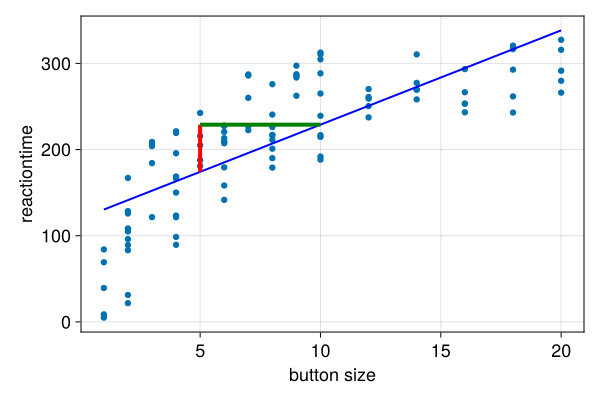

$$reactiontime = \beta_0 + buttonSize * \beta_1$$
Red Line: $[reactiontime | buttonSize=10] - [reactiontime | buttonSize=5]$

$=\beta_0 + 10\beta_1 - (\beta_0 + 5\beta_1)$ $=5\beta_1$

## Which line to choose?

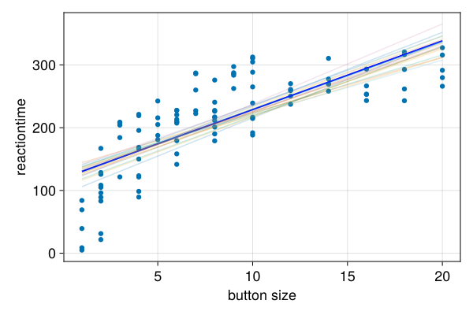

## Residuals / L2 Norm

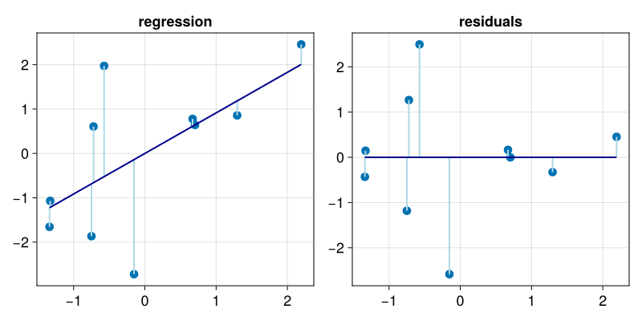

Minimizing the residuals maximizes the fit

L2-Norm (Least Squares): $min(|residual_i|_2)$

## In our example

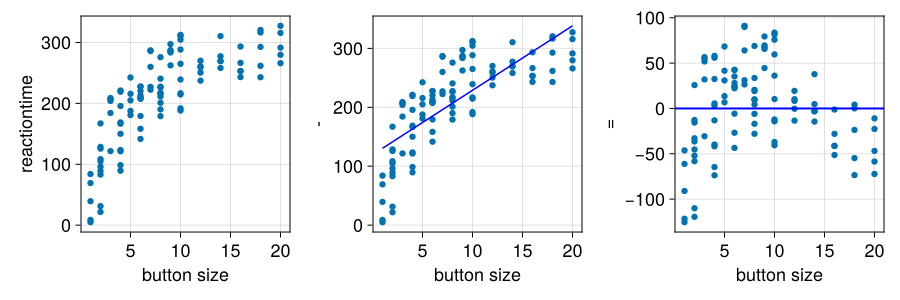

Data: $y = \beta_0 + x_1 \beta_1 + e_i$

Prediction: $\hat{y} = \beta_0 + x_1 \beta_1$

Residuals: $e_i = y - \hat{y}$

## in Julia

```julia
fit = lm(@formula(reactiontime ~ 1 + button_size), d)
coeftable(fit)
```

|  | Coef. | Std. Error | t | Pr(>\|t\|) | Lower 95% | Upper 95% |
| --- | --- | --- | --- | --- | --- | --- |
| (Intercept) | 119.401 | 9.1716 | 13.02 | <1e-22 | 101.2 | 137.601 |
| button_size | 10.9463 | 0.934856 | 11.71 | <1e-19 | 9.09112 | 12.8015 |

## Explained Variance

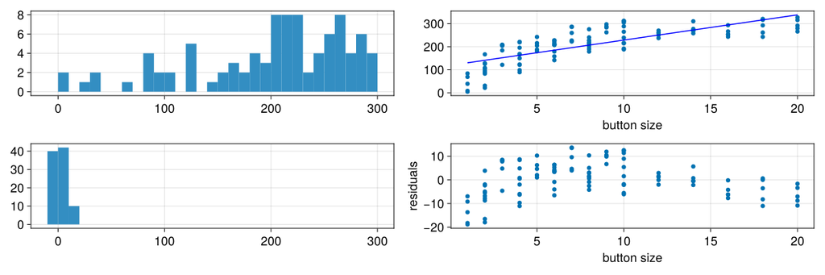

$var(y)$ vs. $var(e)$ $R^2 = 1 - \frac{var(e)}{var(y)}$

## Single outlier

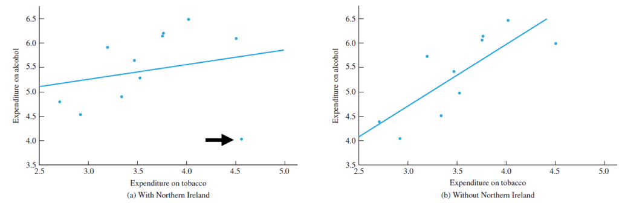

Especially true for small sample sizes

# Multiple Regression

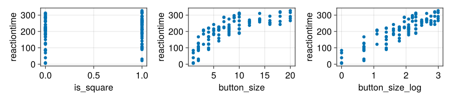

```julia
fit_multi = lm(@formula(reactiontime ~ 1 + button_size + is_square + button_size_log), d)
coeftable(fit_multi)
```

|  | Coef. | Std. Error | t | Pr(>\|t\|) | Lower 95% | Upper 95% |
| --- | --- | --- | --- | --- | --- | --- |
| (Intercept) | 49.3006 | 8.98408 | 5.49 | <1e-06 | 31.4674 | 67.1339 |
| button_size | -0.0691646 | 1.47265 | -0.05 | 0.9626 | -2.99236 | 2.85403 |
| is_square | -54.9997 | 6.75506 | -8.14 | <1e-11 | -68.4084 | -41.591 |
| button_size_log | 101.495 | 9.6174 | 10.55 | <1e-17 | 82.4045 | 120.585 |

## With two predictors you span a plane

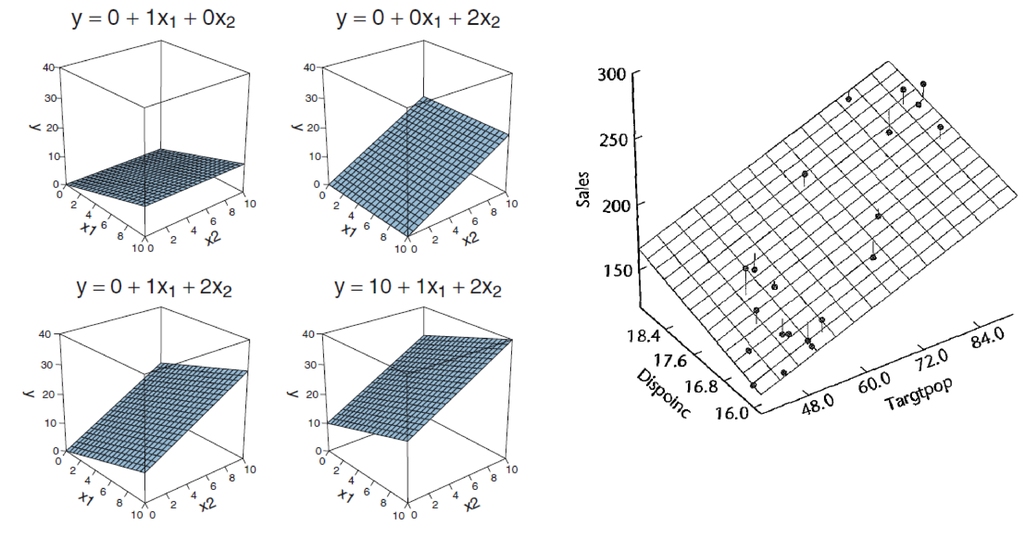

two predictors span a plane

## Overlapping variance

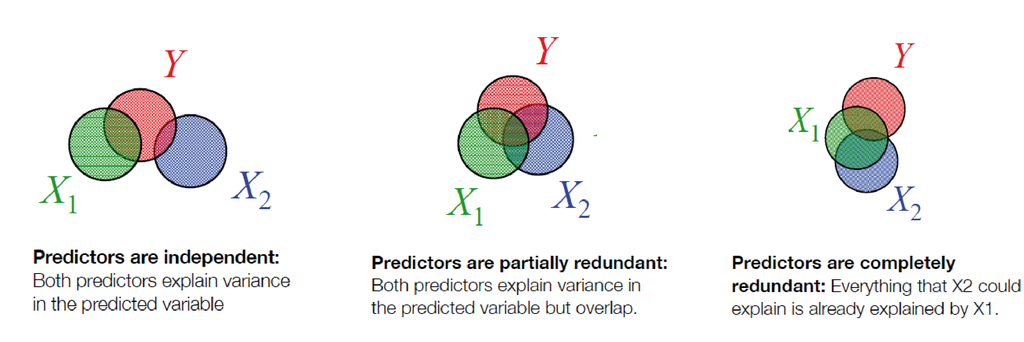

venn diagram of variance explained

## Perfect redundant

```julia
data_redundant = copy(d)
data_redundant.button_size_scaled = data_redundant.button_size .* 10
coeftable(lm(@formula(reactiontime ~ button_size + button_size_scaled), data_redundant))
```

|  | Coef. | Std. Error | t | Pr(>\|t\|) | Lower 95% | Upper 95% |
| --- | --- | --- | --- | --- | --- | --- |
| (Intercept) | 119.401 | 9.1716 | 13.02 | <1e-22 | 101.2 | 137.601 |
| button_size | 0.0 | NaN | NaN | NaN | NaN | NaN |
| button_size_scaled | 1.09463 | 0.0934856 | 11.71 | <1e-19 | 0.909112 | 1.28015 |

## Partially redundant

```julia
data_redundant = copy(d)
data_redundant.button_size_noise = data_redundant.button_size .+ randn(nrow(data_redundant)) .* 0.5
coeftable(lm(@formula(reactiontime ~ button_size), data_redundant))
coeftable(lm(@formula(reactiontime ~ button_size + button_size_noise), data_redundant))
```

|  | Coef. | Std. Error | t | Pr(>\|t\|) | Lower 95% | Upper 95% |
| --- | --- | --- | --- | --- | --- | --- |
| (Intercept) | 121.619 | 9.18813 | 13.24 | <1e-22 | 103.383 | 139.855 |
| button_size | 26.6002 | 9.47262 | 2.81 | 0.0060 | 7.79963 | 45.4007 |
| button_size_noise | -15.8467 | 9.54331 | -1.66 | 0.1000 | -34.7875 | 3.09416 |

Multicollinearity is usually not so obvious

## Suppressors: Including unrelated variables can improve modelfit

[output not shown]

|  | Coef. | Std. Error | t | Pr(>\|t\|) | Lower 95% | Upper 95% |
| --- | --- | --- | --- | --- | --- | --- |
| (Intercept) | 0.0736531 | 0.131952 | 0.56 | 0.5789 | -0.190478 | 0.337784 |
| OV | -0.00695822 | 0.0129088 | -0.54 | 0.5919 | -0.032798 | 0.0188815 |

## a graphical intuition

[figure not shown]

surpressor animation

## A shorthand notation

$y_i = 1*\beta_0 + x_{i,1}*\beta_1 + x_{i,2}*\beta_2 + ... + x_{i,n}*\beta_n + e_i$

is nothing else than matrix multiplication

$y = X\beta+e$

$X = designmatrix$ with size $[n_{datapoints},n_{predictors}]$

$e = residuals$with size $[n_{datapoints}]$

## Designmatrix & algebra

```
100×4 Matrix{Float64}:
 1.0   1.0  0.0  0.0
 1.0   2.0  1.0  0.693147
 1.0   1.0  0.0  0.0
 1.0   2.0  1.0  0.693147
 1.0   1.0  0.0  0.0
 1.0   2.0  1.0  0.693147
 1.0   1.0  0.0  0.0
 1.0   2.0  1.0  0.693147
 1.0   1.0  0.0  0.0
 1.0   2.0  1.0  0.693147
 ⋮
 1.0  20.0  1.0  2.99573
 1.0  10.0  0.0  2.30259
 1.0  20.0  1.0  2.99573
 1.0  10.0  0.0  2.30259
 1.0  20.0  1.0  2.99573
 1.0  10.0  0.0  2.30259
 1.0  20.0  1.0  2.99573
 1.0  10.0  0.0  2.30259
 1.0  20.0  1.0  2.99573
```

$$y = X\beta$$
Can be solved by:
$$\beta = (X^TX)^{-1}X^Ty$$

# Categorical Variables

## Dummy Coding

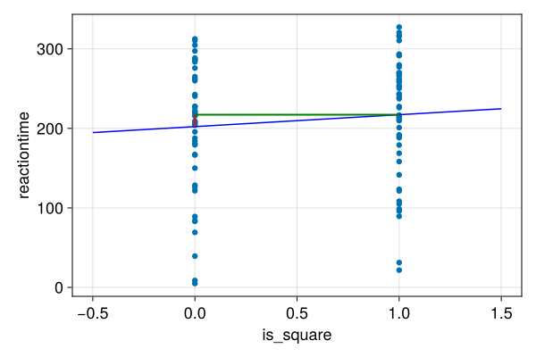

We code the categorical variable with 0 / 1

$y_i = \beta_0 + is\_square *\beta_1 + e_i$

## Interpretation

$y_i = \beta_0 + is\_square *\beta_1 + e_i$

- $\beta_0$ / Intercept: reactiontime when $is\_square$ equals 0 (round)
- $\beta_1$ / Slope: additional reactiontime when switching from round to square

```julia
fit_shape_factor = lm(@formula(reactiontime ~ 1 + is_square), data_factor)
coeftable(fit_shape_factor)
```

|  | Coef. | Std. Error | t | Pr(>\|t\|) | Lower 95% | Upper 95% |
| --- | --- | --- | --- | --- | --- | --- |
| (Intercept) | 202.222 | 10.8191 | 18.69 | <1e-33 | 180.752 | 223.692 |
| is_square | 14.9708 | 15.3006 | 0.98 | 0.3303 | -15.3927 | 45.3342 |

## Effect Coding aka sum coding aka deviation coding

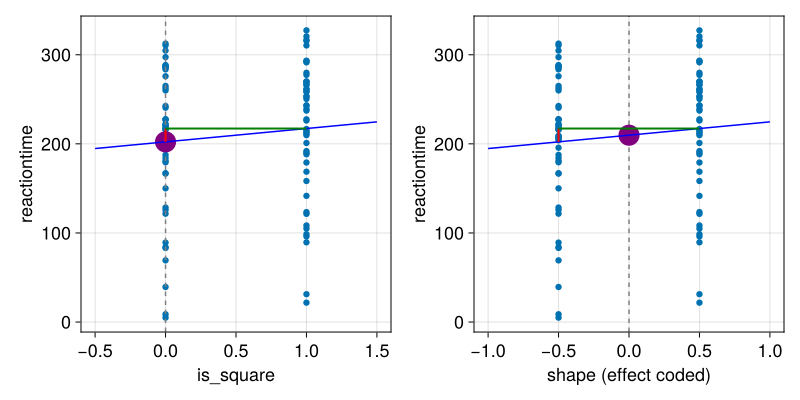

Using effect coding, the interpretation of the intercept changes to the mean between groups

warning: often effect coding is made using -1 and 1, then the $\beta_1$ is halve the size! using 0.5 is much more practical

## Multiple levels

```
9×3 Matrix{Float64}:
 1.0  0.0  0.0
 1.0  0.0  0.0
 1.0  0.0  0.0
 1.0  1.0  0.0
 1.0  1.0  0.0
 1.0  1.0  0.0
 1.0  0.0  1.0
 1.0  0.0  1.0
 1.0  0.0  1.0
```

Treatment / Dummy Coding

```
9×3 Matrix{Float64}:
 1.0  -0.5  -0.5
 1.0  -0.5  -0.5
 1.0  -0.5  -0.5
 1.0   0.5   0.0
 1.0   0.5   0.0
 1.0   0.5   0.0
 1.0   0.0   0.5
 1.0   0.0   0.5
 1.0   0.0   0.5
```

Effect Coding

# Main effects and interactions

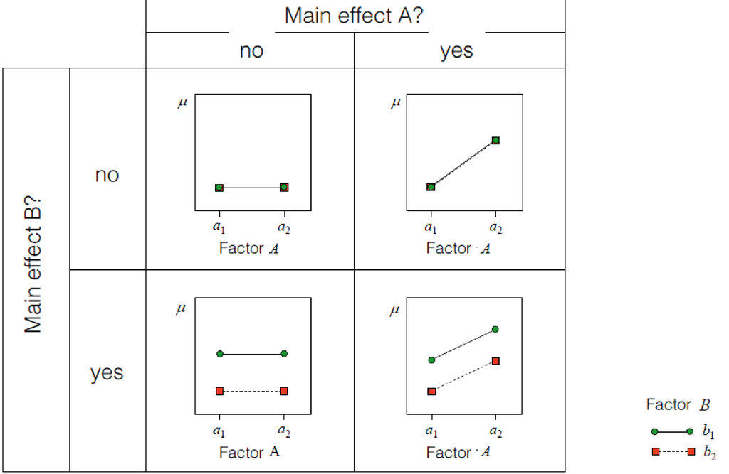

errorbars/data-points ommited for clarity

## Interaction effects

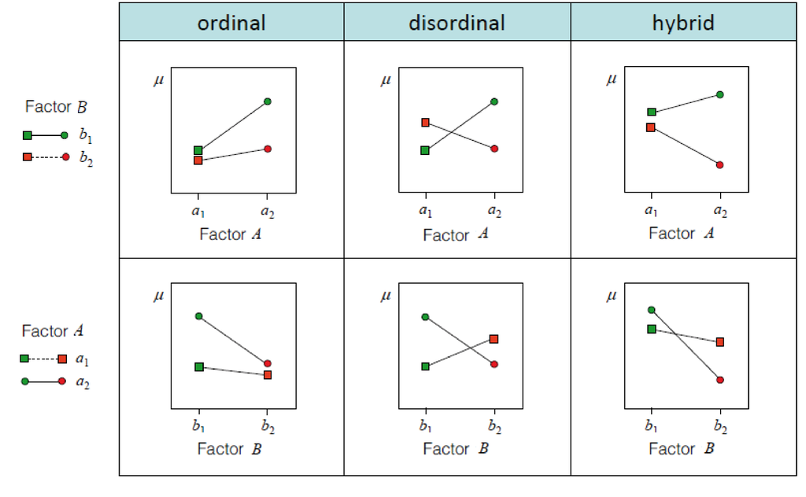

interaction effects

not really helpful to learn these names

## How are interactions coded

$y = \beta_0 + factorA * \beta_1 + factorB * \beta_2 + factorA * factorB * \beta_3$

Different words for the same thing:

- The interaction shows how much the prediction needs to be changed, when both factors co-occur
- The interaction is the multiplication of the columns in X of factorA and factorB
- The interaction represents the difference of differences

## Interactions of continuous/categorical predictors

$y = \beta_0 + factorA * \beta_1 + contB * \beta_2 + factorA * contB * \beta_3$

|  | Coef. | Std. Error | t | Pr(>\|t\|) | Lower 95% | Upper 95% |
| --- | --- | --- | --- | --- | --- | --- |
| (Intercept) | -37.7034 | 41.5057 | -0.91 | 0.3714 | -122.724 | 47.3172 |
| wt | 54.774 | 10.9877 | 4.99 | <1e-04 | 32.2666 | 77.2813 |
| am: 1 | 27.2841 | 78.5006 | 0.35 | 0.7308 | -133.517 | 188.085 |
| wt & am: 1 | -11.3233 | 32.382 | -0.35 | 0.7292 | -77.6548 | 55.0083 |

## The difference between main and simple effects

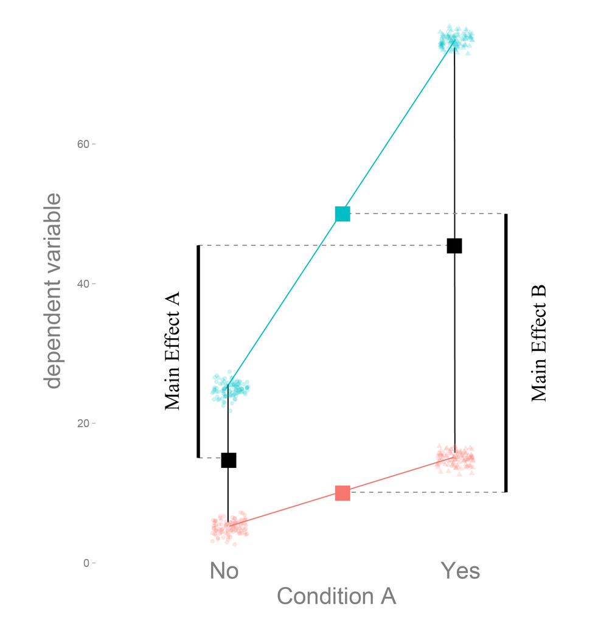

Dummy coding tests simple effects

Effect coding main effects